## R code for analysis of the Spirit Cave faunal data.

Cyler Conrad, Department of Anthropology, University of New Mexico, cylerc@unm.edu

Ben Marwick, Department of Anthropology, University of Washington, bmarwick@uw.edu

This document contain R code to reproduce the plots and statistical analysis presented in

> Conrad, C., Higham, C. and Eda, M. (in press) Paleoecology and Forager Subsistence Strategies During the Pleistocene-Holocene Transition: A Reinvestigation of the Zooarchaeological Assemblage from Spirit Cave, Mae Hong Son Province, Thailand. Asian Perspectives.

All data required to perform the analyses can be found at the University of New Mexico digital electronic repository (Conrad 2015). The development version of this document can be found at https://github.com/cylerc/AP_SC

References: Conrad, C. 2015. Archaeological Databases for Spirit Cave, Mae Hong Son Province, Thailand [dataset]. University of New Mexico. http://repository.unm.edu/handle/1928/26730

```r
# set the base directory for knitr to the directory above this one
# install.packages(c("knitr", "Bchron", "car", "ggplot2", "reshape2", "dplyr"))
library(knitr)
opts_knit$set(root.dir = '../', progress = FALSE)
```

```r
# see the output of sessionInfo() at the bottom for package version numbers
library(Bchron)
library(car)
library(ggplot2)
library(reshape2)
library(plyr)
library(dplyr)
library(viridis)
```

```r
# 1. Calibrate Spirit Cave radiocarbon dates.
dates <- read.csv("data/dates.csv", stringsAsFactors = FALSE, check.names = FALSE)
ages <- BchronCalibrate(ages = dates$Ages,
                     ageSds = dates$ageSds,
                     positions = c(1,1,1,2,2,"2a","3/4",4,4),
                     calCurves = rep("intcal13", length(dates$Ages)))
# show tables of calibrated age ranges for each date
summary(ages)
```

```
## Highest density regions for date1
##       [,1]   [,2]   [,3]   [,4]   [,5]   [,6]
## 99% 3078.8 3093.5 3108.9 3127.0 3139.1 3365.5
## 95% 3160.0 3356.7     NA     NA     NA     NA
## 50% 3210.0 3253.5 3293.9 3326.5     NA     NA
##
## Highest density regions for date2
##       [,1]   [,2]   [,3]   [,4]
## 99% 3002.5 3278.2 3280.7 3344.0
## 95% 3061.2 3266.4 3288.0 3335.6
## 50% 3082.9 3090.0 3144.1 3217.5
##
## Highest density regions for date3
##       [,1]   [,2]   [,3]   [,4]   [,5]   [,6]   [,7]   [,8]
## 99% 7508.1 7546.4 7551.8 9093.9 9100.2 9121.0     NA     NA
## 95% 7666.2 8793.0 8827.8 8866.8 8882.2 8899.1 8911.2 8974.8
## 50% 8008.0 8400.3     NA     NA     NA     NA     NA     NA
##
## Highest density regions for date4
##       [,1]   [,2] [,3]    [,4]  [,5]    [,6]  [,7]  [,8]
## 99% 7736.2 9941.7 9992 10008.6 10029 10035.6 10062 10130
## 95% 7945.0 9661.7   NA      NA    NA      NA    NA    NA
## 50% 8429.0 9027.6   NA      NA    NA      NA    NA    NA
##
## Highest density regions for date5
##       [,1]   [,2]   [,3]    [,4]   [,5]    [,6]
## 99% 8814.6 8823.0 8874.7  8875.3 8978.9 10242.3
## 95% 9092.2 9104.5 9116.0 10160.6     NA      NA
## 50% 9327.9 9343.0 9402.4  9736.3     NA      NA
##
## Highest density regions for date6
##       [,1]    [,2] [,3]   [,4]   [,5]   [,6]
## 99% 8590.8 10414.0   NA     NA     NA     NA
## 95% 8767.0 10239.7   NA     NA     NA     NA
## 50% 9257.0  9781.5 9851 9857.6 9879.5 9880.7
##
## Highest density regions for date7
##        [,1]    [,2]
## 99% 11315.8 15199.0
## 95% 11816.2 14878.1
## 50% 12740.0 13580.0
##
## Highest density regions for date8
##       [,1]    [,2]    [,3]  [,4]    [,5]  [,6]  [,7]    [,8]
## 99% 9150.0  9163.4  9252.1 11759      NA    NA    NA      NA
## 95% 9471.0 11286.2      NA    NA      NA    NA    NA      NA
## 50% 9941.7  9992.0 10008.6 10029 10035.6 10062 10130 10711.3
##
## Highest density regions for date9
##        [,1]    [,2]    [,3]    [,4]    [,5]    [,6]
## 99% 10588.0 10633.2 10642.7 14549.1      NA      NA
## 95% 11166.8 14030.2      NA      NA      NA      NA
## 50% 12240.8 12271.8 12309.9 12323.9 12380.3 13275.6
```

[output not shown]

[output not shown]

[output not shown]

[output not shown]

[output not shown]

[output not shown]

[output not shown]

[output not shown]

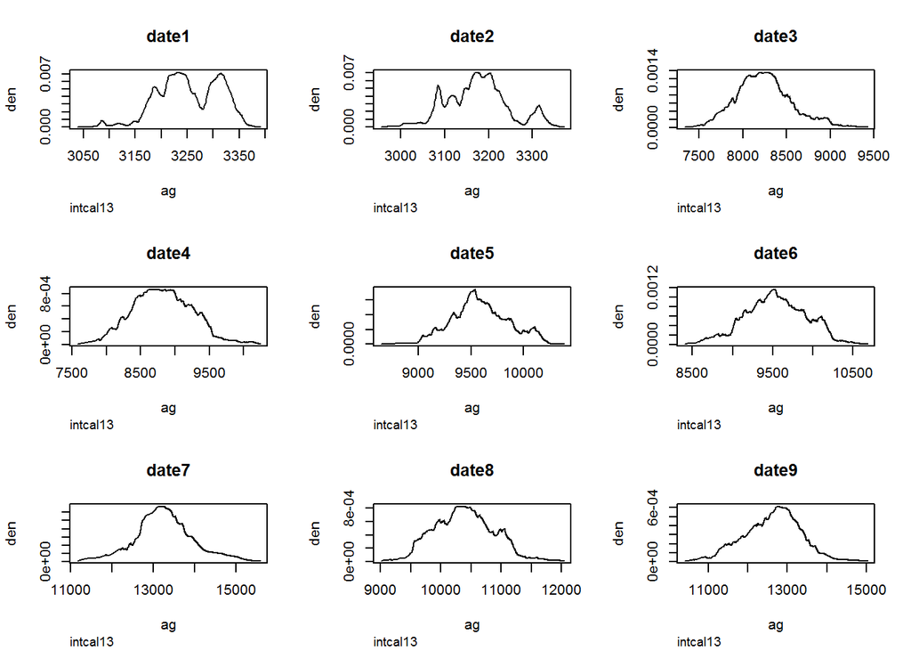

```r
# see plots of all calibrated dates
par(mfrow=c(3, 3)) # set up a grid of 3x3 plots
plot(ages) # put all the plots on that grid
```

```r
# combine all the calibrated dates into a single plot (using results = 'hide' to hide the progress bar)
ages_densities <- BchronDensity(ages = dates$Ages,
                     ageSds = dates$ageSds,
                     calCurves = rep("intcal13", length(dates$Ages)))
```

```r
par(mfrow=c(1,1)) # reset so that the next plot is normal sized.
tiff("analysis/figures/Figure4.tif", res=600, compression = "lzw", height=5, width=5, units="in") # save as high resolution tif
plot(ages_densities, xlab='Age (cal years BP)')
dev.off()
```

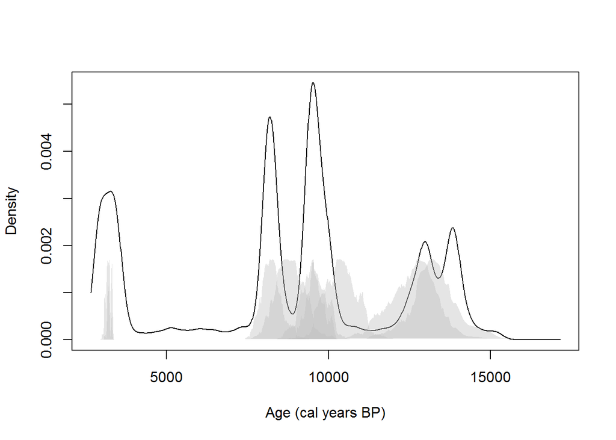

```r
# and show the plot when we knit this
plot(ages_densities, xlab='Age (cal years BP)')
```

```r
#2. Calculate ratios of NRSP/NISP per layer at SC. Analyze these values with Spearmans rho to see if they are driven by sample size.
sc <- read.csv("data/sc.csv", stringsAsFactors = FALSE, check.names = FALSE)

# calculates NISPs per layer without the Mammalia, sm/md/lg/intermediate, Vertebrate sm/md, indeterminate and Indeterminate values, and column totals.

NISP <- sc[c(1:32,37:50), -1]
row.names(NISP) <- sc$Taxon[c(1:32,37:50)]

# compute NRSP (total number of specimens)

NRSP <- unname(colSums(sc[ ,-1]))

# and now the ratio of NRSP to NISP

NRSP_NISP <-  NRSP / colSums(NISP)

# spearman's rho on the ratios to sample size
NRSP_NISP_cor <- cor.test(NRSP, unname(colSums(NISP)), method = 'spearman')
NRSP_NISP_cor_r <-  unname(NRSP_NISP_cor$estimate)
NRSP_NISP_cor_p <-  round(NRSP_NISP_cor$p.value, 3)
```

The Spearman’s rho values for the NRSP/NISP to sample size relationship are:

r = 0.9  
p = 0.083

```r
# compute NTAXA

NTAXA <- unname(colSums(sc!= 0))[-1]

# spearman's rho on the NTAXA to sample size
NTAXA_cor <- cor.test(NTAXA, unname(colSums(NISP)), method = 'spearman')
NTAXA_cor_r <-  unname(NTAXA_cor$estimate)
NTAXA_cor_p <-  round(NTAXA_cor$p.value, 3)
```

The Spearman’s rho values for the NTAXA to sample size relationship are:

r = 0.7  
p = 0.233

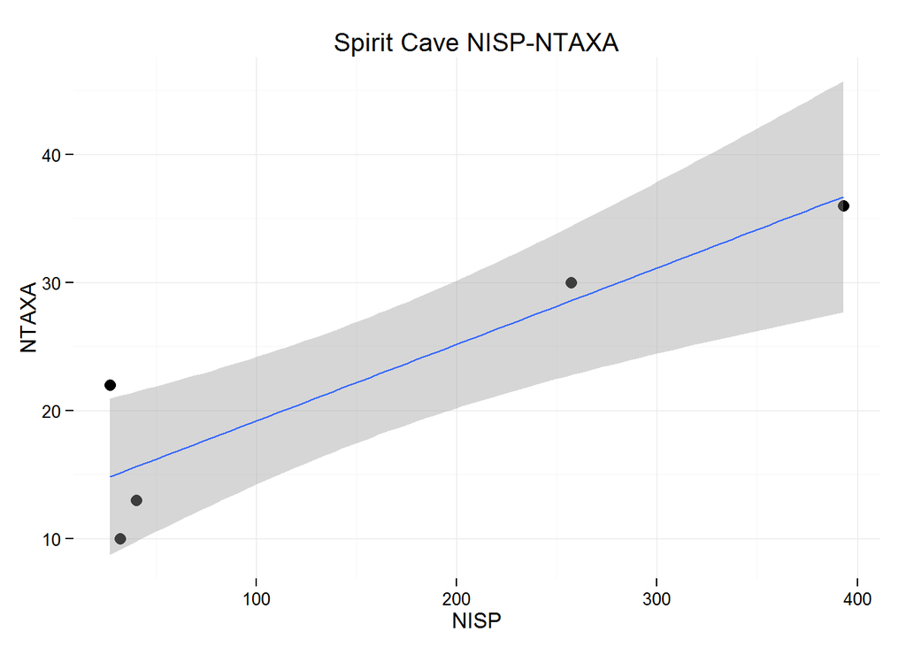

```r
#3. Linear regression analysis of NISP to NTAXA, Cook's distance and leverage analysis of these values and Spearmans rho test with sample size.

# NISP to NTAXA

scn <-  data_frame(NISP = colSums(NISP),
                   NTAXA = NTAXA)

ggplot(scn, aes(NISP, NTAXA)) +
  geom_point(size = 3) +
  geom_smooth(method = "glm") +
  theme_minimal() +
  ggtitle("Spirit Cave NISP-NTAXA")
```

```r
# GLM with poisson
glm.nisp.ntaxa.p <- glm(NTAXA ~ NISP, data = scn, family = poisson)

# chi-sqi to check goodness of fit
pchisq(summary(glm.nisp.ntaxa.p)$deviance,
       summary(glm.nisp.ntaxa.p)$df.residual)
```

```
## [1] 0.8750859
```

```r
# if >0.05, then model gives a good fit.

summary(glm.nisp.ntaxa.p)
```

```
##
## Call:
## glm(formula = NTAXA ~ NISP, family = poisson, data = scn)
##
## Deviance Residuals:
##       1        2        3        4        5
## -1.4705   0.5807  -0.7040   1.6318  -0.2885
##
## Coefficients:
##              Estimate Std. Error z value Pr(>|z|)
## (Intercept) 2.6546620  0.1577222  16.831  < 2e-16 ***
## NISP        0.0024849  0.0006003   4.139 3.48e-05 ***
## ---
## Signif. codes:  0 '***' 0.001 '**' 0.01 '*' 0.05 '.' 0.1 ' ' 1
##
## (Dispersion parameter for poisson family taken to be 1)
##
##     Null deviance: 22.611  on 4  degrees of freedom
## Residual deviance:  5.741  on 3  degrees of freedom
## AIC: 33.921
##
## Number of Fisher Scoring iterations: 4
```

```r
glm.nisp.ntaxa_summary <- summary(glm.nisp.ntaxa.p)
glm.nisp.ntaxa_summary_t <- round(glm.nisp.ntaxa_summary$coefficients[3], 3)
glm.nisp.ntaxa_summary_p <- round(glm.nisp.ntaxa_summary$coefficients[4], 3)

# cook's distance
tiff("analysis/figures/Figure6.tif", res=600, compression = "lzw", height=5, width=5, units="in") # save as high resolution tif
plot(glm.nisp.ntaxa.p, which=5)
dev.off()
```

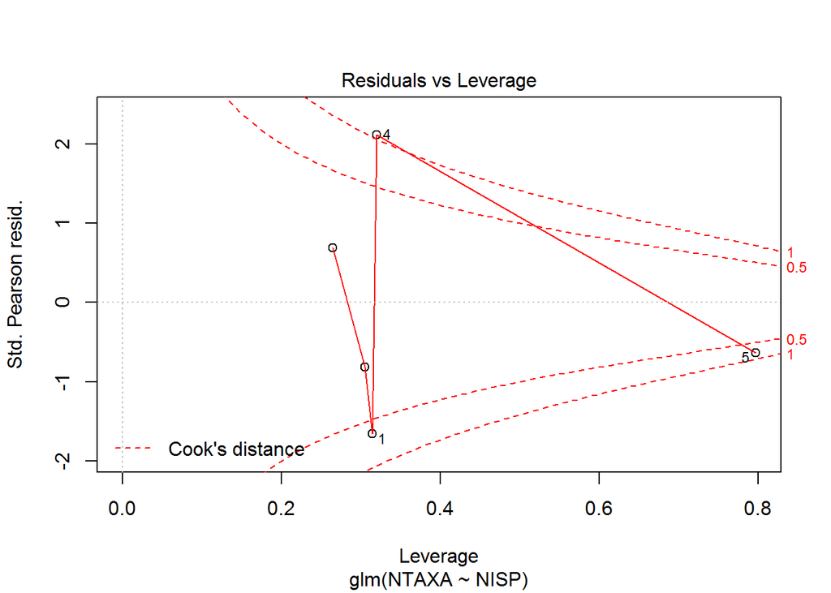

```r
# and show when knit
plot(glm.nisp.ntaxa.p, which=5)
```

```r
# r-squared values, from https://stat.ethz.ch/pipermail/r-help/2010-June/243113.html

# possibility 1
glm.nisp.ntaxa_summary_p_r2 <- cor(NTAXA, predict(glm.nisp.ntaxa.p))^2

# possibility 2
# glm.nisp.ntaxa_summary_p_r2 <- 1 - (sum((NTAXA - predict(glm.nisp.ntaxa.p))^2) / sum((NTAXA - mean(NTAXA))^2))
```

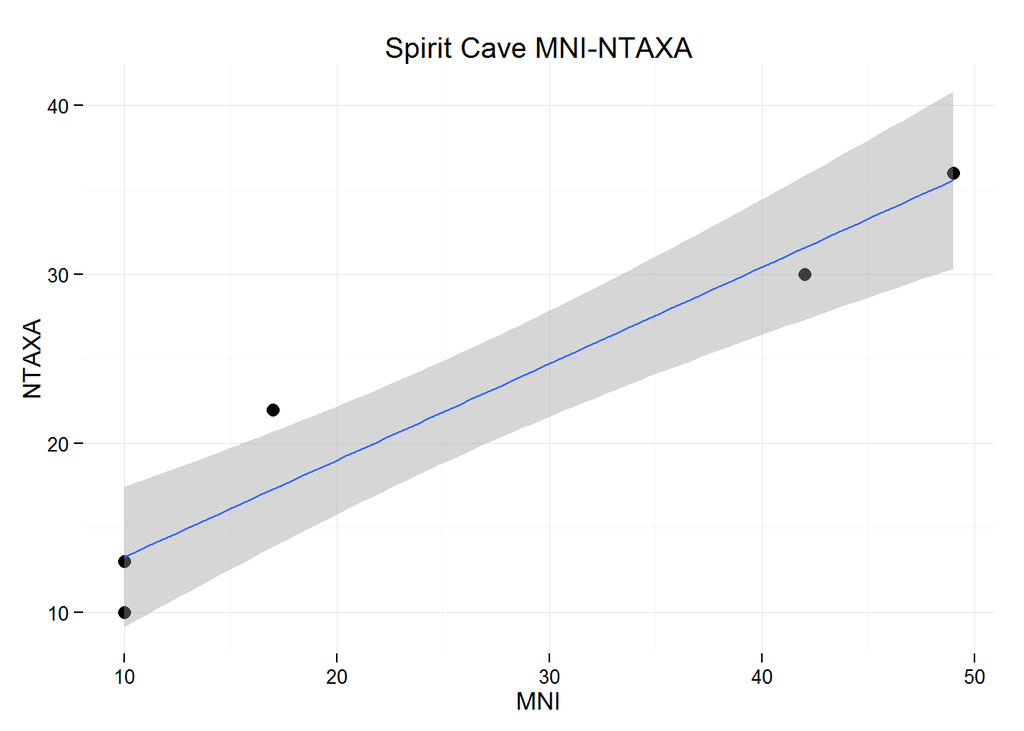

```r
#3.2 MNI to NTAXA.
MNI <- read.csv("data/MNI.csv", stringsAsFactors = FALSE, check.names = FALSE)
MNI <- colSums(MNI[,3:7], na.rm = TRUE)

scm <- data_frame(MNI = unname(MNI),
                  NTAXA = NTAXA)

ggplot(scm, aes(MNI, NTAXA)) +
  geom_point(size = 3) +
  geom_smooth(method = "glm") +
  theme_minimal() +
  ggtitle("Spirit Cave MNI-NTAXA")
```

```r
# GLM with poisson
glm.mni.ntaxa.p <- glm(NTAXA ~ MNI, data = scm, family = poisson)

# chi-sqi to check goodness of fit
pchisq(summary(glm.mni.ntaxa.p)$deviance,
       summary(glm.mni.ntaxa.p)$df.residual)
```

```
## [1] 0.5973798
```

```r
# if >0.05, then model gives a good fit.


summary(glm.mni.ntaxa.p)
```

```
##
## Call:
## glm(formula = NTAXA ~ MNI, family = poisson, data = scm)
##
## Deviance Residuals:
##        1         2         3         4         5
## -1.06311  -0.11386  -0.20378   1.31838  -0.08183
##
## Coefficients:
##             Estimate Std. Error z value Pr(>|z|)
## (Intercept) 2.370638   0.209703  11.305  < 2e-16 ***
## MNI         0.025030   0.005721   4.375 1.21e-05 ***
## ---
## Signif. codes:  0 '***' 0.001 '**' 0.01 '*' 0.05 '.' 0.1 ' ' 1
##
## (Dispersion parameter for poisson family taken to be 1)
##
##     Null deviance: 22.6110  on 4  degrees of freedom
## Residual deviance:  2.9295  on 3  degrees of freedom
## AIC: 31.109
##
## Number of Fisher Scoring iterations: 4
```

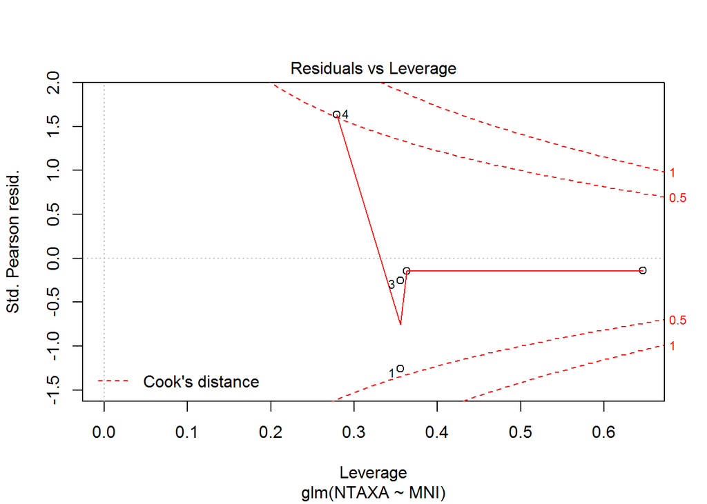

```r
glm.mni.ntaxa_summary <- summary(glm.mni.ntaxa.p)
glm.mni.ntaxa_summary_t <- round(glm.mni.ntaxa_summary$coefficients[3], 3)
glm.mni.ntaxa_summary_p <- round(glm.mni.ntaxa_summary$coefficients[4], 3)

# cook's distance
plot(glm.mni.ntaxa.p, which = 5)
```

```r
# r-squared values, from https://stat.ethz.ch/pipermail/r-help/2010-June/243113.html

# possibility 1
glm.mni.ntaxa_r2 <- cor(NTAXA, predict(glm.mni.ntaxa.p))^2

# possibility 2
# glm.mni.ntaxa_r2 <- 1 - (sum((NTAXA - predict(glm.mni.ntaxa.p))^2) / sum((NTAXA - mean(NTAXA))^2))
```

```r
# 4.1 Chi-square test between Layer 4 and 3.

sc_layer_3_and_4 <-  as.data.frame((sc[, 5:6]))

# exclude taxa with no counts
sc_layer_3_and_4 <- sc_layer_3_and_4[!rowSums(sc_layer_3_and_4) == 0, ]

# compute chi-sq
sc_layer_3_and_4_chisq.summary <- chisq.test(t(sc_layer_3_and_4), correct = FALSE)
# 4.2 Chi-square test between Layer 3 and 2a.

sc_layer_3_and_2a <-  as.data.frame((sc[, 4:5]))

# exclude taxa with no counts
sc_layer_3_and_2a <- sc_layer_3_and_2a[!rowSums(sc_layer_3_and_2a) == 0, ]

# compute chi-sq
sc_layer_3_and_2a_chisq.summary <- chisq.test(t(sc_layer_3_and_2a), correct = FALSE)
# 4.3 Chi-square test between Layer 2a and 2.

sc_layer_2_and_2a <-  as.data.frame((sc[, 3:4]))

# exclude taxa with no counts
sc_layer_2_and_2a <- sc_layer_2_and_2a[!rowSums(sc_layer_2_and_2a) == 0, ]

# compute chi-sq
sc_layer_2_and_2a_chisq.summary <- chisq.test(t(sc_layer_2_and_2a), correct = FALSE)
# 4.4 Chi-square test between Layer 2 and 1.

sc_layer_1_and_2 <-  as.data.frame((sc[, 2:3]))

# exclude taxa with no counts
sc_layer_1_and_2 <- sc_layer_1_and_2[!rowSums(sc_layer_1_and_2) == 0, ]

# compute chi-sq
sc_layer_1_and_2_chisq.summary <- chisq.test(t(sc_layer_1_and_2), correct = FALSE)
# table of all chi-sq values
my_chi_sqs <- list(sc_layer_1_and_2_chisq.summary,
                     sc_layer_2_and_2a_chisq.summary,
                     sc_layer_3_and_2a_chisq.summary,
                     sc_layer_3_and_4_chisq.summary)

# extract chi-sq, df, and p-values into a table
my_chi_sqs_df <- ldply(my_chi_sqs, function(i) c(unname(i$statistic), unname(i$parameter),  i$p.value))
# add col names
names(my_chi_sqs_df) <- c('chi-sq', 'df', 'p')
# add row names
my_chi_sqs_df$layers <- c("1_and_2", "2_and_2a", "2a_and_3", "3_and_4")
# rearrange the cols to put names first
my_chi_sqs_df <- my_chi_sqs_df[,c(4,1:3)]
# show the table
my_chi_sqs_df
```

```
##     layers    chi-sq df             p
## 1  1_and_2  134.0758 33  3.894024e-14
## 2 2_and_2a  275.8448 32  1.344798e-40
## 3 2a_and_3  200.6761 29  1.386933e-27
## 4  3_and_4 1482.1522 42 1.505718e-283
```

```r
#5. Analysis of burnt bone NISPs and sample size using Spearmans rho.

burn <- read.table(text="
                  NISP NRSP
                  9 44
                  72 373
                  16 113
                  30 107
                  194 1767
                  ", header=TRUE)
burn
```

```
##   NISP NRSP
## 1    9   44
## 2   72  373
## 3   16  113
## 4   30  107
## 5  194 1767
```

```r
# spearman's rho on the ratios to sample size
burn_NRSP_NISP_cor <- cor.test(burn$NISP, burn$NRSP, method = 'spearman')
burn_NRSP_NISP_cor_cor_r <-  unname(burn_NRSP_NISP_cor$estimate)
burn_NRSP_NISP_cor_cor_p <-  round(burn_NRSP_NISP_cor$p.value, 3)
```

[output not shown]

LICENSE

The MIT License (MIT)

Copyright (c) 2015 Cyler Conrad & Ben Marwick

Permission is hereby granted, free of charge, to any person obtaining a copy of this software and associated documentation files (the “Software”), to deal in the Software without restriction, including without limitation the rights to use, copy, modify, merge, publish, distribute, sublicense, and/or sell copies of the Software, and to permit persons to whom the Software is furnished to do so, subject to the following conditions:

The above copyright notice and this permission notice shall be included in all copies or substantial portions of the Software.

THE SOFTWARE IS PROVIDED “AS IS”, WITHOUT WARRANTY OF ANY KIND, EXPRESS OR IMPLIED, INCLUDING BUT NOT LIMITED TO THE WARRANTIES OF MERCHANTABILITY, FITNESS FOR A PARTICULAR PURPOSE AND NONINFRINGEMENT. IN NO EVENT SHALL THE AUTHORS OR COPYRIGHT HOLDERS BE LIABLE FOR ANY CLAIM, DAMAGES OR OTHER LIABILITY, WHETHER IN AN ACTION OF CONTRACT, TORT OR OTHERWISE, ARISING FROM, OUT OF OR IN CONNECTION WITH THE SOFTWARE OR THE USE OR OTHER DEALINGS IN THE SOFTWARE.